# Better planning, healthier babies

The correlation between Low Birth Weight (LBW) and access to family planning

**2025** it’s a critical time to reassess one of UNICEF’s main concerns: **Low Birth Weight (LBW)**.  
In 2012, the World Health Organization (WHO) Health Assembly set six global nutrition targets for 2025, including a **30% reduction in LBW rates**. By the end of this year, the world will know whether this goal has been achieved.But in the meantime, let’s learn about this relevant world challenge…

#### But first things first…

**WHAT IS IT?**  
Low Birth Weight (LBW) is defined by the World Health Organization as weight at birth less than 2,500grams (5.5 lb). By 2012, when the 30% reduction goal was set, it was estimated that 15 - 20% of worldwide births were low birth weight, representing more than 20 million babies a year.

**WHY DOES IT MATTER?**  
According to the WHO LBW babies have higher risk of: stunting, lower IQ, adult overweight and obesity, heart diseases, diabetes, etc.

#### Back in 2012…

When the WHO set the 30% LBW reduction goal, the countries with highest percentages of LBW were in Asia and Africa. By analyzing UNICEF data, we can notice that indeed, these are the regions with the highest challenges on LBW.  
But which countries, and which percentage of their births are LBW? And also, which countries have the best results for this issue? *Let’s take a look…*

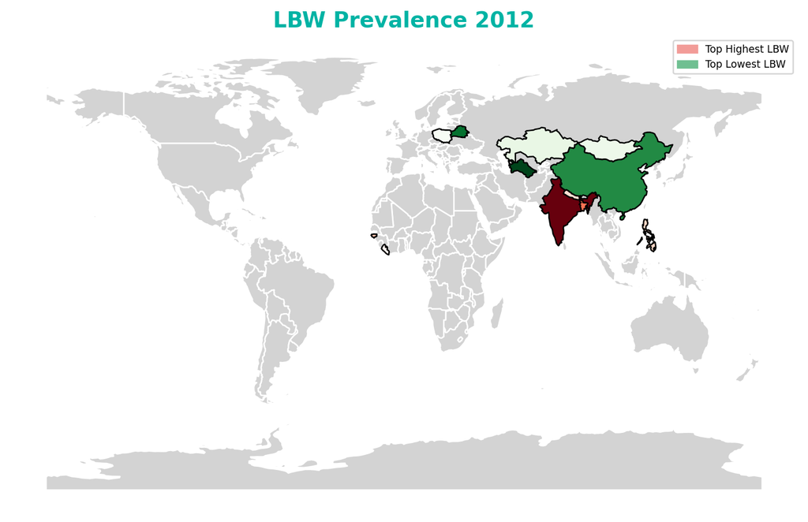

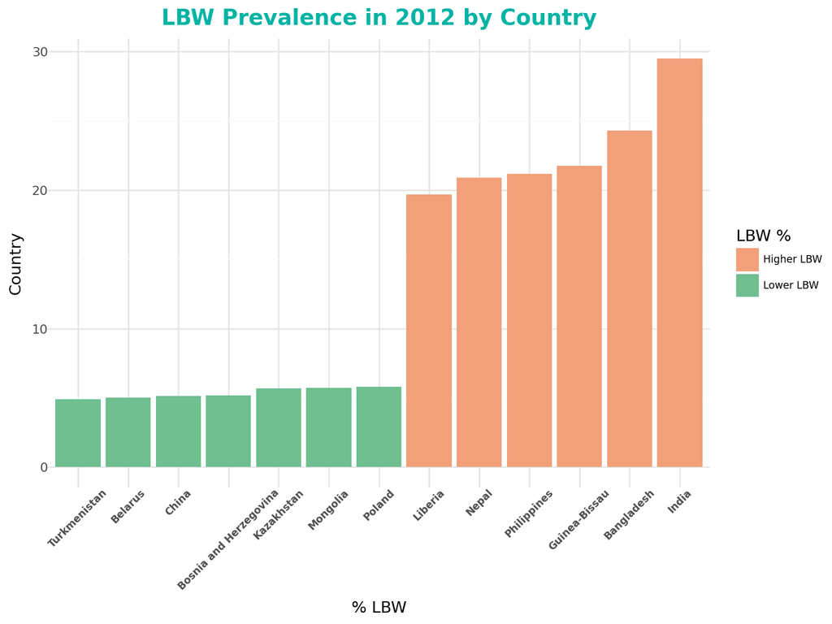

```python
#MAP MAP MAP MAP MAP MAP
import geopandas as gpd
import polars as pl
import pandas as pd
import matplotlib.pyplot as plt
world = gpd.read_file('/content/drive/MyDrive/ColabNotebooks/GoogleColab_Final/ne_110m_admin_0_map_units/ne_110m_admin_0_map_units.shp')
#world = gpd.read_file("countries/ne_110m_admin_0_countries.shp")
#world = gpd.read_file("https://public.opendatasoft.com/api/explore/v2.1/catalog/datasets/world-administrative-boundaries/exports/shp")
file_path = '/content/drive/MyDrive/ColabNotebooks/GoogleColab_Final/unicef_indicator_1_prevalence_lowbith.csv'
df = pl.read_csv(file_path)
higher_countries = ["India", "Bangladesh", "Guinea-Bissau", "Philippines", "Nepal", "Liberia"]
lower_countries = ["Belarus", "Bosnia and Herzegovina", "China", "Kazakhstan", "Mongolia", "Poland", "Turkmenistan"]

selected_countries = higher_countries + lower_countries

df_2012 = df.filter(
    (pl.col("time_period") == 2012) &
    (pl.col("country").is_in(selected_countries))
)
df_plot = df_2012.to_pandas()

df_red = df_plot[df_plot["country"].isin(higher_countries)]
df_green = df_plot[df_plot["country"].isin(lower_countries)]
merged_red = world.merge(df_red, left_on="NAME", right_on="country", how="left")
merged_green = world.merge(df_green, left_on="NAME", right_on="country", how="inner")
import matplotlib.pyplot as plt
import matplotlib.patches as mpatches

fig, ax = plt.subplots(figsize=(10, 6))
ax.set_aspect('equal')

world.plot(ax=ax, color='lightgrey', edgecolor='white')
merged_red.plot(
    ax=ax,
    column='obs_value',
    cmap='Reds',
    legend=False,
    edgecolor='black'
)
merged_green.plot(
    ax=ax,
    column='obs_value',
    cmap='Greens_r',
    legend=False,
    edgecolor='black'
)

red_patch = mpatches.Patch(color='#F29C98', label='Top Highest LBW')
green_patch = mpatches.Patch(color='#6FBF91', label='Top Lowest LBW')
ax.legend(handles=[red_patch, green_patch], loc='upper right', fontsize=7, frameon=True)

ax.set_title("LBW Prevalence 2012", fontsize=15, fontweight='bold', color='#00B3A4')
ax.set_axis_off()
plt.show()

fig.savefig("lbw_map_2012_red_green.png", dpi=300, bbox_inches='tight')

#BAR CHART BAR CHART BAR CHART BAR CHART
df_plot = df_2012.to_pandas()
df_plot["LBW %"] = df_plot["country"].apply(
    lambda x: "Higher LBW" if x in higher_countries else "Lower LBW"
)

from plotnine import *

df_plot_sorted = df_plot.sort_values(by="obs_value", ascending=True)

(
    ggplot(df_plot_sorted, aes(x='reorder(country, obs_value)', y='obs_value', fill='LBW %')) +
    geom_col(show_legend=True) +
    scale_fill_manual(values={"Higher LBW": "#F1A07A", "Lower LBW": "#6FBF91"}) +
    labs(
        title="LBW Prevalence in 2012 by Country",
        x="% LBW",
        y="Country",
    ) +
    theme_minimal() +
    theme(figure_size=(8, 6),
          legend_position='right',
          legend_text=element_text(size=7),
          axis_text_x=element_text(rotation=45, size=7, weight="bold"),
          plot_title=element_text(
            color="#00B3A4",
            weight="bold",
            size=15,
            ha='center'
          )
)
)
```

#### But how to improve?

The WHO and UNICEF have set different “actions to drive progress in reducing low birth weight”. These interventions to prevent low birth weight are mainly related to preterm birth and gestational age. Some of these interventions include: promotion of smoking cessation, daily iron and folic acid supplements for pregnant women, fetal growth monitoring and neonatal size evaluation at all levels, and many more. But are those interventions enough?

#### What if?…

Improving LBW rates could involve more than just direct interventions? By analyzing the countries with the best LBW outcomes, we can explore what’s working for them. One key indicator to analyze is the demand for family planning satisfied with modern methods (% of women aged 15-49). This is important because interventions could start even before pregnancy. Let’s explore the relationship between these two indicators…

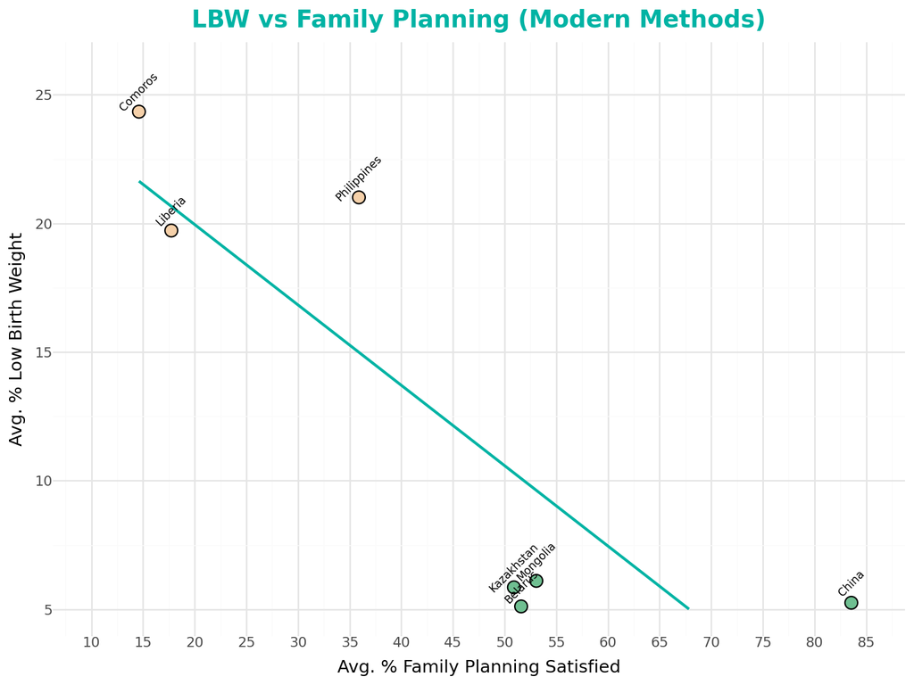

```python
#SCATTERPLOT SCATTERPLOT SCATTERPLOT SCATTERPLOT SCATTERPLOT
import polars as pl
from plotnine import *
import pandas as pd

countries = ["China", "Mongolia", "Belarus", "Kazakhstan", "Philippines", "Liberia", "Comoros", "Guinea"]
green_countries = ["China", "Mongolia", "Belarus", "Kazakhstan"]
red_countries = ["Guinea", "Comoros", "Liberia", "Philippines"]

#LBW
df_lbw = pl.read_csv('/content/drive/MyDrive/ColabNotebooks/GoogleColab_Final/unicef_indicator_1_prevalence_lowbith.csv')
df_lbw = df_lbw.filter(pl.col("country").is_in(countries))
df_lbw_avg = df_lbw.group_by("country").agg(pl.col("obs_value").mean().alias("avg_lbw"))

#Fam planning %
df_fp = pl.read_csv('/content/drive/MyDrive/ColabNotebooks/GoogleColab_Final/unicef_indicator_2_family_planning.csv')
df_fp = df_fp.filter(pl.col("country").is_in(countries))
df_fp_avg = df_fp.group_by("country").agg(pl.col("obs_value").mean().alias("avg_family_planning"))


df_combined = df_lbw_avg.join(df_fp_avg, on="country")
df_combined_pd = df_combined.to_pandas()

df_combined_pd["Group"] = df_combined_pd["country"].apply(
    lambda x: "Lower LBW" if x in green_countries else
              "Higher LBW" if x in red_countries else "Other"
)

(
    ggplot(df_combined_pd, aes(x='avg_family_planning', y='avg_lbw')) +
    geom_point(aes(fill='Group'), size=4, shape='o') +
    geom_smooth(method='lm', color="#00B3A4", se=False) +
    geom_text(aes(label='country'), nudge_y=0.75, size=7, angle=45) +
    scale_fill_manual(values={
        "Lower LBW": "#6FBF91",
        "Higher LBW": "#F5D0A9"
    }) +
    labs(
        title="LBW vs Family Planning (Modern Methods)",
        x="Avg. % Family Planning Satisfied",
        y="Avg. % Low Birth Weight",
        fill="LBW vs FDP"
    ) +
    theme_minimal() +
    theme(
        figure_size=(8, 6),
     legend_position="none",
     plot_title=element_text(
            color="#00B3A4",
            weight="bold",
            size=15,
            ha='center'
     )
    ) +
    scale_x_continuous(limits=(10, 85), breaks=range(10, 86, 5)) +
    scale_y_continuous(limits=(5, 26), breaks=range(5, 27, 5))


)
```

While achieving UNICEF’s goal is important, it is equally crucial to recognize that LBW and other newborn health challenges can be addressed even earlier. Ensuring progress on critical health indicators, such as family planning, can reduce LBW and improve maternal and infant health. Better planning can lead to healthier babies.

#### NEPAL

If we take a look at Nepal and its performance on both indicators in the past years, we can see that even though they need to keep improving on their family planning demand satisfaction and lower their LBW, they are proof that as the family planning demand with modern methods is satisfied, the lower cases of LBW.

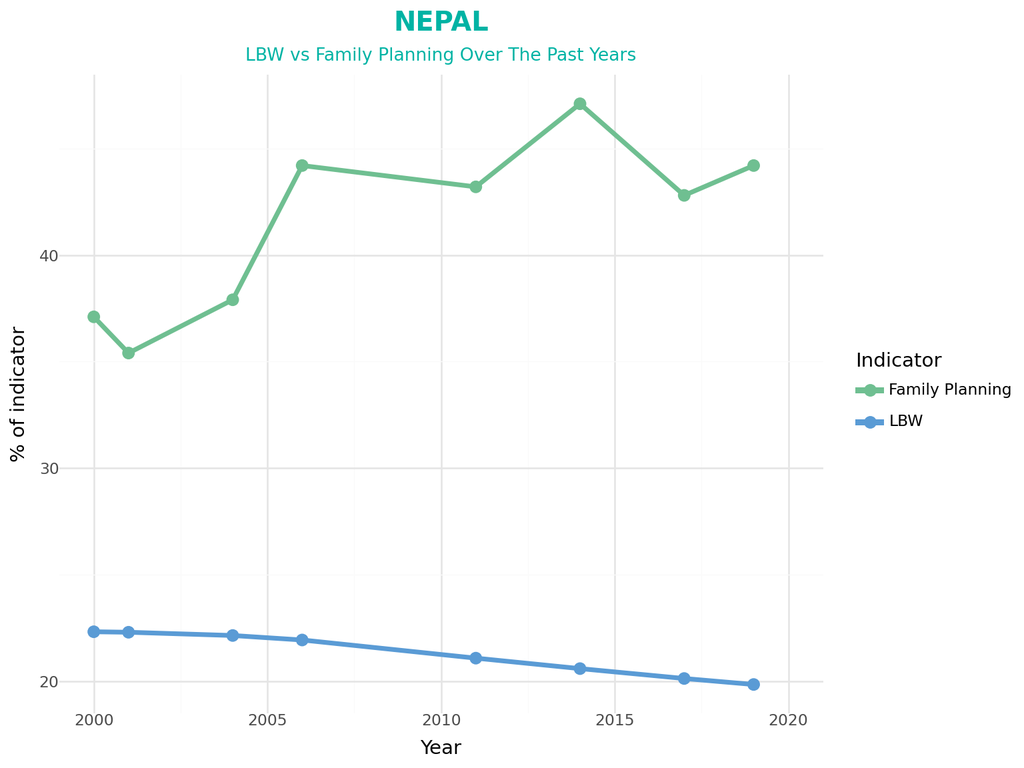

```python
import polars as pl
import pandas as pd
from plotnine import *

#NEPAL
country = "Nepal"
years = [2000, 2001, 2004, 2006, 2011, 2014, 2017, 2019]

# ---------- LBW ----------
df_lbw = pl.read_csv('/content/drive/MyDrive/ColabNotebooks/GoogleColab_Final/unicef_indicator_1_prevalence_lowbith.csv')
df_lbw = df_lbw.filter(
    (pl.col("country") == country) &
    (pl.col("time_period").is_in(years))
).select(["time_period", "obs_value"])
df_lbw = df_lbw.with_columns(pl.lit("LBW").alias("indicator"))

# ---------- Fam pLAN ----------
df_fp = pl.read_csv('/content/drive/MyDrive/ColabNotebooks/GoogleColab_Final/unicef_indicator_2_family_planning.csv')
df_fp = df_fp.filter(
    (pl.col("country") == country) &
    (pl.col("time_period").is_in(years))
).select(["time_period", "obs_value"])
df_fp = df_fp.with_columns(pl.lit("Family Planning").alias("indicator"))

#
df_combined = pl.concat([df_lbw, df_fp])
df_combined_pd = df_combined.to_pandas()

# ---------- G R A P H  ----------
(
    ggplot(df_combined_pd, aes(x='time_period', y='obs_value', color='indicator', group='indicator')) +
    geom_line(size=1.5) +
    geom_point(size=3) +
    labs(
        title="NEPAL",
        subtitle= "LBW vs Family Planning Over The Past Years",
        x="Year",
        y="% of indicator",
        color="Indicator"
    ) +
    scale_x_continuous(breaks=years) +
    scale_x_continuous(limits=(2000, 2020)) +
    scale_color_manual(
        values={
            "Family Planning": "#6FBF91",
            "LBW": "#5A9BD5"
        }
    ) +
    theme_minimal() +
    theme(
        figure_size=(8, 6),
        plot_title=element_text(color="#00B3A4", weight="bold", size=15, ha='center'),
        plot_subtitle=element_text(color="#00B3A4", size=10, ha='center')
)
)
```

#### Conclusion

This challenge will not stop by 2025 and it’s essential to continue working to reduce LBW rates, but including earlier interventions such as family planning demand satisfaction can be key to achieve lower LBW rates.

[figure not shown]